# ESM 206 Final Assignment

Cameryn Brock

12/9/2019

## Task 1. Predicting penguin mass

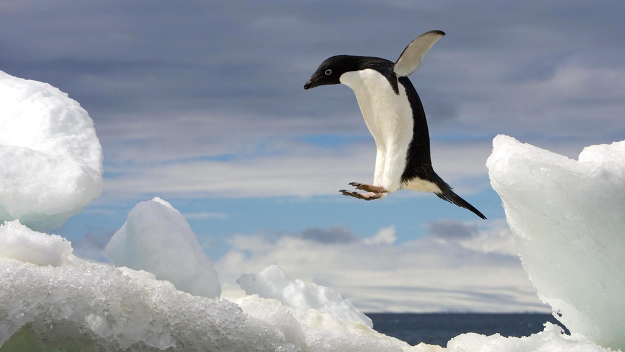

Adelie Penguin (*Pygoscelis adeliae*) jumping into finals week. Credit: [Ralph Lee Hopkins, *National Geographic*](https://kids.nationalgeographic.com/animals/birds/adelie-penguin/)

Here we explored the potential for predicting penguin mass in Adelie, Chinstrap, and Gentoo penguins considering flipper length, sex, and species. We used data recorded at Palmer Station, LTER, Antarctica, compiled from the Environmental Data Initative (Gorman 2017).

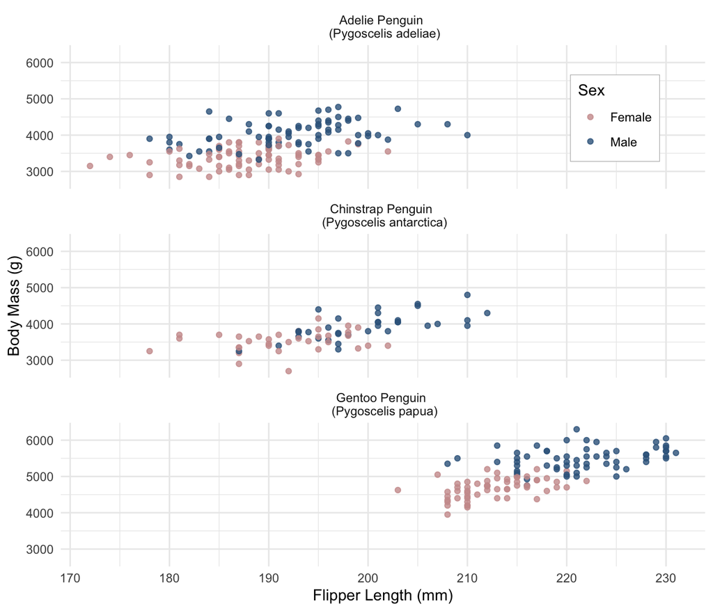

**Figure 1.** Penguin species, sex, flipper length, and body mass. Data was recorded at Palmer Station, LTER, Antarctica and compiled from the Environmental Data Initiative (Gorman 2017)

**Key Takeaways**

**Table 1.** Summary of a multi-linear regression for predicting penguin body mass (g) with sex (male, female), flipper length (mm), and species (adelie, gentoo, chinstrap) as predictive variables. The data analyzed was recorded at Palmer Station, LTER, Antarctica and compiled from the Environmental Data Initiative (Gorman 2017)

|  | *Dependent variable:* |
| --- | --- |
|  | Body Mass (g) |
| Flipper Length (mm) | 20.025*** |
|  | (2.846) |
| Species: Chinstrap | -87.634* |
|  | (46.347) |
| Species: Gentoo | 836.260*** |
|  | (85.185) |
| Sex: Male | 530.381*** |
|  | (37.810) |
| Constant | -365.817 |
|  | (532.050) |
| Observations | 333 |
| R<sup>2</sup> | 0.867 |
| Adjusted R<sup>2</sup> | 0.865 |
| Residual Std. Error | 295.565 (df = 328) |
| F Statistic | 534.024*** (df = 4; 328) |
| *Note:* | p<0.1; p<0.05; p<0.01 |

Our adjusted R<sup>2</sup>, or coefficient of determination, of 0.865 means that 86.5% of the variance in penguin body mass is predictable from penguin flipper length, species, and sex.

- **Flipper Length**: we expect body mass to be 20.03g *more* on average for each 1mm increase in flipper length, if all other variables remain the same.
- **Species, Chinstrap**: we expect Chinstrap penguins to weigh 87.63g on average *less* than Adelie penguins, if all other variables remain the same.
- **Species, Gentoo**: we expect Gentoo penguins to weigh 836.26g, on average, *more* than Adelie penguins, if all other variables remain the same.
- **Sex, Male**: we expect male penguins to weigh 530.38g, on average, *more* than female penguins, if all other variables remain the same.

**Table 2.** Predicted values for body mass (g) with our multi linear regression model. Predictive variables include species, sex, and flipper length (mm). Data was recorded at Palmer Station, LTER, Antarctica, compiled from the Environmental Data Initiative (Gorman 2017).

| Species | Sex | Flipper Length (mm) | Predicted Body Mass (g) |
| --- | --- | --- | --- |
| Chinstrap Penguin | Female | 195 | 3451 |
| Adelie Penguin | Male | 205 | 4270 |
| Gentoo Penguin | Male | 220 | 5406 |

## Task 2. Smoking effects on baby birth weight

We analyzed the relationship between birth weight and whether women reported smoking during pregnancy by reviewing the proportions (Table 3) and testing significance with a chi-square test for independence. Birth weights were defined as low (below 5lb 8oz) or not low and responses to whether mothers smoked were categorized as yes or no. The data used was released by the state of North Carolina in 2004.

**Table 3.** Proportions and counts for low (< 5lb 8oz) and not low birth weights born to mothers who reported that they smoked or did not smoke during pregnancy. The data used was released by the state of North Carolina in 2004.

|  | Not Low Birth Weight | Low Birth Weight |
| --- | --- | --- |
| Did Not Smoke | 781 (89%) | 92 (11%) |
| Smoked | 108 (86%) | 18 (14%) |

Both mothers that did not report smoking and that did had the majority of births at not low birth weight (781 (89%) and 108 (86%), respectively). We did not find a siginificant association between birth weight and smoking during pregnancy for the levels analyzed ($\chi^2$ (1) = 1.22, p = 0.27).

This data may contain biases associated with the survey methods; for example, due to social pressure or errors in hindsight women may be inclined to claim that they did not smoke during pregnancy even if they did. Offering a Likert Scale would not only provide more data, but could also lessen this bias associated with a strict yes or no questionnaire.

## Task 3. Visualizing UCSB campus profiles

We compared the percentage of white and minority students of total UCSB undergraduate students from 2008-2018 to demonstrate how the relative proportions are changing over time (Figure 2). Data is compiled from the annual UCSB Campus Profiles prepared by the Office of Budget and Planning through the Institutional Research, Planning, & Assessment Initiative (UCSB). This dataset includes graduate and undergraduate students; however, we only used data for undergraduate students. Additionally, this dataset provides data for eight categories of ethnicities; however, to simplify for our purposes, we grouped the two categories with the smallest proportions of the total (American Indian / Alaskan students and E. Indian / Pakistani) within the ‘Other’ category. Lastly, again to simplify, we titled the Asian / Pacific Islander category as ‘Asian’, but this category still includes Pacific Islander students.

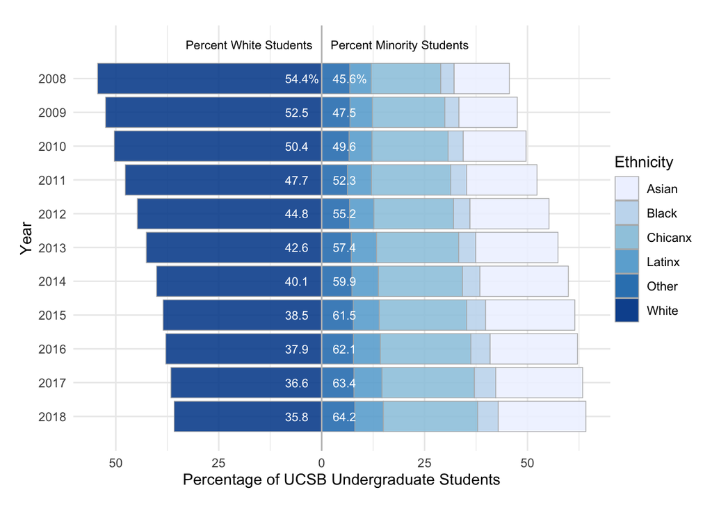

**Key Takeaways**

- At UCSB from 2008-2010, the percentage of white undergraduate students was higher than the percentage of all minority undergraduate students combined (>50%).
- In 2011, the percentage of white undergraduate students was lower than the percentage of collective minority undergraduate students for the first time (in this data set). The percentage of collective minority students continued to increase 2011-2018.
- Much of the increase in the percentage of collective minority students is due to an increase in the percentage of Asian and Chicanx students. The percentage of Asian and Chicanx students increased by 7.9% and 6.0% from 2008 to 2018, respectively.

## Task 4. Purple urchins on the Santa Barbara coast

We explored size distributions of purple sea urchins (*Strongylocentrotus purpuratus*) at five sites along the Santa Barbara coast. The data is from SBC LTER long-term kelp removal experiment sites (Reed 2019). We only examined data from control treatments, where no kelp was removed.

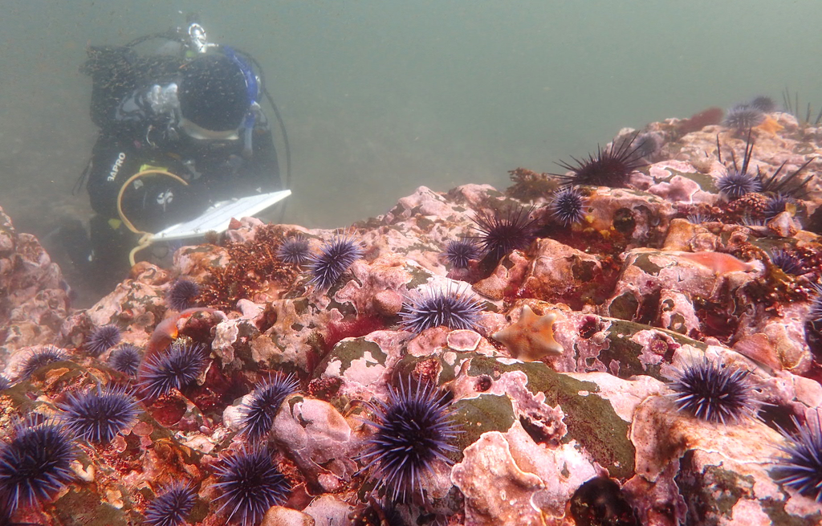

Purple sea urchins (*Strongylocentrotus purpuratus*). Credit: Cynthia Catton, *California Department of Fish and Wildlife*

**Table 4.** Summary of data for purple sea urchins in control treatments in five sites along the Santa Barbara Coast (2008-2018). Data is provided by SBC LTER (Reed 2019).

| Site | Mean Size | Standard Deviation | Standard Error | Variance | Sample Size |
| --- | --- | --- | --- | --- | --- |
| Mohawk | 5.28 | 1.14 | 0.02 | 1.30 | 3510 |
| Arroyo Quemado | 4.57 | 1.04 | 0.02 | 1.08 | 3185 |
| Isla Vista | 4.25 | 0.94 | 0.02 | 0.89 | 1601 |
| Carpinteria | 4.17 | 1.13 | 0.02 | 1.28 | 3430 |
| Naples | 4.05 | 1.11 | 0.02 | 1.23 | 3219 |

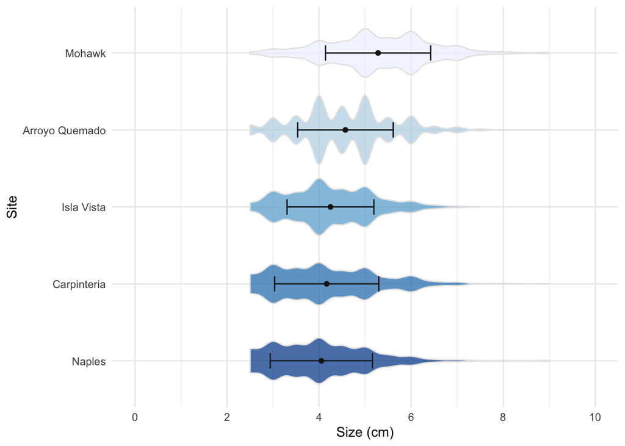

**Figure 4.** Urchin size distributions at five sites along the Santa Barbara coast (2008-2018). Error bars show the mean and standard deviation for urchin size. Data is provided by SBC LTER (Reed 2019).

**Key Takeaways**

- Mean urchin sizes and size distributions are very similar at Isla Visa, Carpinteria, and Naples, and only slightly larger at Arroyo Quemado.
- Mean urchin size is the largest at Mohawk. Mean urchin size at Mohawk is ~1.25cm more than at the site with the smallest mean urchin size, Naples, and ~ 0.75cm more than at the next largest site, Arroyo Quemado.

We analyzed observations for purple urchin size from 2008-2018 at all five sites (see Table 4 for means and standard deviations for each of the five sites). One-way ANOVA with post-hoc Tukey’s HSD revealed a significant difference in mean urchin size across all five sites (F(4, 14940) = 692.99, *p* < 0.001 for all pair-wise comparisons). Table 5 provides a summary of the differences in mean urchin size (cm) among the pair-wise comparisons.

**Table 5**. Differences in mean purple urchin size (cm) in among pair-wise comparisons from five sites along the Santa Barbara Coast (2008-2018) calculated in a post-hoc Tukey’s HSD analysis. Size varied significantly among all sites (p < 0.001 for all comparisons). Rows are listed from largest to smallest mean urchin size and columns are listed from smallest to largest (see Table 4 for mean urchin sizes). Data is provided by SBC LTER (Reed 2019).

| Site | Naples | Carpinteria | Isla Vista | Arroyo Quemado | Mohawk |
| --- | --- | --- | --- | --- | --- |
| Mohawk | 1.23 | 1.12 | 1.03 | 0.71 |  |
| Arroyo Quemado | 0.52 | 0.41 | 0.32 |  | -0.71 |
| Isla Visa | 0.20 | 0.08 |  | -0.32 | -1.03 |
| Carpinteria | 0.12 |  | -0.08 | -0.41 | -1.12 |
| Naples |  | -0.12 | -0.20 | -0.52 | -1.23 |

## References

**Gorman K. 2017.** Structural size measurements and isotopic signatures of foraging among adult male and female Adélie penguins (Pygoscelis adeliae) nesting along the Palmer Archipelago near Palmer Station, 2007-2009. Environmental Data Initiative. https://doi.org/10.6073/pasta/abc50eed9138b75f54eaada0841b9b86.

**Gorman K. 2017.** Structural size measurements and isotopic signatures of foraging among adult male and female chinstrap penguins (Pygoscelis antarctica) nesting along the Palmer Archipelago near Palmer Station, 2007-2009. Environmental Data Initiative. https://doi.org/10.6073/pasta/2b1cff60f81640f182433d23e68541ce.

**Gorman K. 2017.** Structural size measurements and isotopic signatures of foraging among adult male and female gentoo penguins (Pygoscelis papua) nesting along the Palmer Archipelago near Palmer Station, 2007-2009. Environmental Data Initiative. https://doi.org/10.6073/pasta/409c808f8fc9899d02401bdb04580af7.

**Reed D. 2019.** SBC LTER: Reef: Long-term experiment: Kelp removal: Urchin size frequency distribution. Environmental Data Initiative. https://doi.org/10.6073/pasta/846569acc8745c133a44eac40245e6f0.

**UCSB**. Campus Profiles, 2008-2018. Office of Budget and Planning. http://bap.ucsb.edu/institutional.research/campus.profiles/